# Which Technical Skills Are Most In Demand in Tech Hiring?

Yuzhuo Cui

2026-09-16

## Introduction

Tech hiring has always been competitive, while the skills employers ask for shift constantly. With hundreds of languages, frameworks, and tools competing for attention, it is hard to know where to focus employees’ learning.

This analysis scrapes job postings from three independent sources to answer below question:

**Which technical skills appear most frequently in tech job postings?**

## Where the Data Comes From

I collected job postings from three different platforms, each representing a different slice of the tech hiring market:

| Source | What it covers | Postings |
| --- | --- | --- |
| **RemoteOK** | A curated remote-first job board with structured skill tags | 99 |
| **We Work Remotely** | A remote-only job board with detailed descriptions | 25 |
| **Hacker News “Who is Hiring?”** | Global startup and tech hiring, updated monthly | 245 |

Together these sources cover a certain amount of employers and postings, such as tech companies including startups and traditional companies that hiring across onsite, hybrid, and remote arrangements.

Each platform attracts a different kind of employer, so combining them reduces the risk of drawing conclusions from a single, biased sample.

## The Skills That Keep Appearing in traditional tech-postings are not dominating the remote labor market

From the data, though three platforms are focusing on similar industries, the required abilities are quite different. For traditional Hacker News, **Python** dominates the postings.It appears in 69 of the 245 postings (28%). However, the requirement numbers for Python is other two remote platform are much lower. Especially for RemoteOK, there are only 8 postings mentioned Python in their postings.

### We Work Remotely: 25 Remote Tech Postings

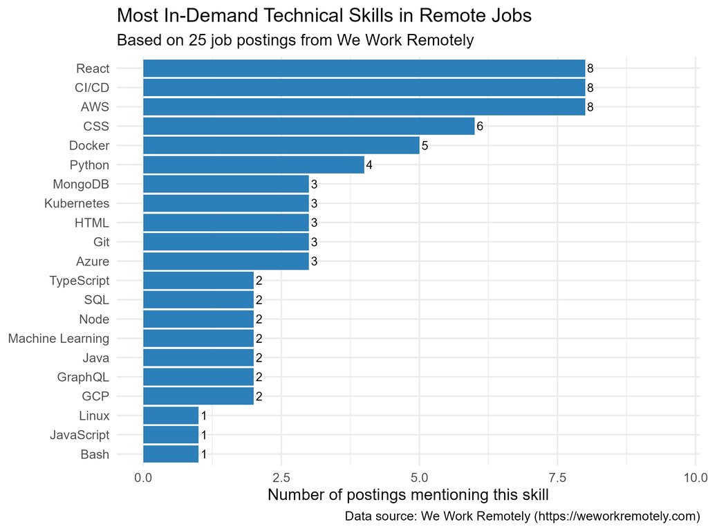

Skills in demand on We Work Remotely

### RemoteOK: 99 Remote-First Postings

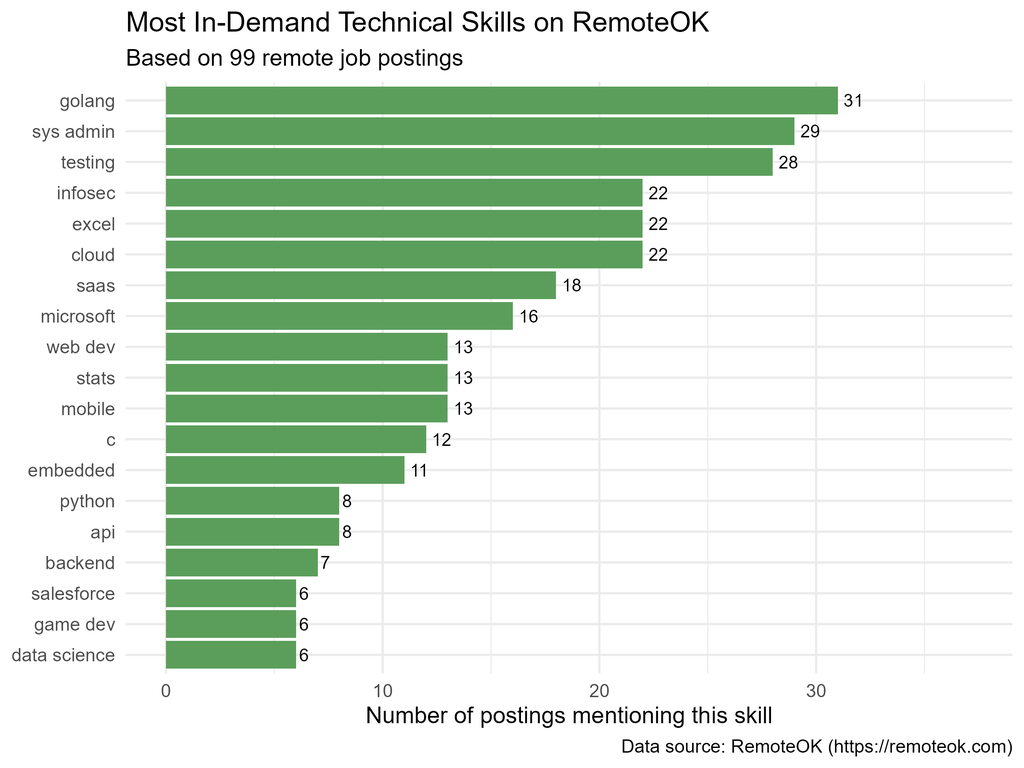

Skills in demand on RemoteOK

RemoteOK’s tag data tells a different story. **Go** and **system administration** dominate, reflecting a user base of infrastructure engineers and DevOps specialists. Backend skills are more prominent here than on the other platforms.

### Hacker News: 245 Global Tech Postings

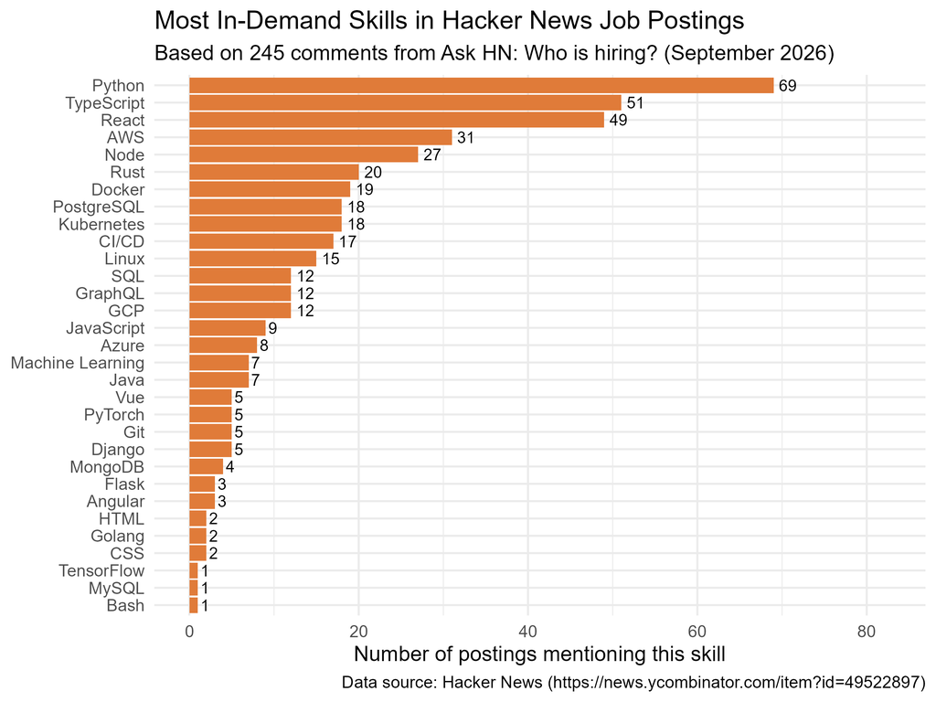

Skills in demand on Hacker News

The Hacker News sample is the largest and most diverse. **Python** leads with 69 mentions (28%), followed by **TypeScript** and **React**. This is the startup-heavy, full-stack profile — engineers who are expected to work across the entire product.

## How the Three Platforms Compare

The most interesting finding is not what the platforms agree on, but where they differ.

[output not shown]

## Conclusion

For someone unsure which segment to target, a low-regret starting point would be Python and React first, then cloud/DevOps literacy.

The broader lesson is methodological: **“What skills are in demand?” is not a well-defined question until you specify the market.** Different platforms serve different employers, and the skills that matter depend on which segment you are targeting.

## What This Analysis Cannot Tell You

A few honest limitations:

- **It is a snapshot.** The data was collected in September 2026 and reflects one moment in a fast-moving market.
- **Job postings are not hires.** Employers list many skills they never actually test for. Advertised demand is a rough proxy for real demand.
- **Keyword counting is imprecise.** A posting that mentions “Python” once counts the same as one that mentions it ten times.

These limitations do not undermine the findings — the patterns are strong enough to be meaningful — but they are worth keeping in mind.

*Data sources: [RemoteOK](https://remoteok.com), [We Work Remotely](https://weworkremotely.com), and [Hacker News](https://news.ycombinator.com/item?id=49522897). All scraping was done ethically using public RSS feeds, APIs, and HTML pages.*